# Perform RDA on sea otter rectal samples

Natasha Dudek

04/12/2018

rmarkdown::render(“/docker_access/sea_otter/vPaper/oral_community_profiles/rda_rectal.Rmd”, clean=TRUE, output_format=“html_document”)

Note: the clustering portion of this analysis is based on that done in  
DiGiulio, D.B., et al. “Temprectal and spatial variation of the human microbiota during pregnancy.” Proceedings of the National Academy of Sciences 112.35 (2015): 11060-11065.

## Initialize

```r
setwd("/docker_access/sea_otter/vPaper/oral_community_profiles")
getwd()
```

```
## [1] "/docker_access/sea_otter/vPaper/oral_community_profiles"
```

Load libraries

```r
library("phyloseq"); packageVersion("phyloseq")
```

```
## [1] '1.23.1'
```

```r
library("ggplot2"); packageVersion("ggplot2")
```

```
## [1] '2.2.1'
```

```r
library("cluster"); packageVersion("cluster") # used for clustering samples
```

```
## [1] '2.0.7.1'
```

```r
library("factoextra"); packageVersion("factoextra") # used for gap statistic calculations
```

```
## [1] '1.0.5'
```

```r
library("DESeq2"); packageVersion("DESeq2") # used for differential abundance analysis
```

```
## [1] '1.16.1'
```

```r
library("grid"); packageVersion("grid") # needed to plot heatmap
```

```
## [1] '3.4.1'
```

```r
library("vegan"); packageVersion("vegan") # needed to get eigenvalues from RDA (plot axes proportional to variance explained)
```

```
## [1] '2.5.2'
```

ggplot2 package theme set

```r
theme_set(theme_bw())
```

Load phyloseq object (full otter dataset)

```r
physeq <- readRDS("/docker_access/sea_otter/vPaper/physeq_dec18.rds")
```

```r
physeq <- subset_samples(physeq, facility == "CDFW")
physeq <- subset_samples(physeq, duplicate_capture == "no")
ps_rectal_orig <- subset_samples(physeq, sample_type == "rectal")
```

Transform the data to be proportions  
(this is ok while we are not doing differential abundance analysis)

```r
ps_rectal <- transform_sample_counts(ps_rectal_orig, function(x) x/sum(x))
```

## Cluster into community profiles

Use bray curtis distance metric:  
1. Don’t know if closely related strains may be having an effect -> choose a non-phylogenetically informed metric  
2. If two sets of samples both have species A, but in one set relative abundance is usually 1% and in the other it’s usually 99%, that information is significant -> choose a metric that uses relative abundance

```r
braydist <- phyloseq::distance(ps_rectal, method="bray")
ord = ordinate(ps_rectal, method = "MDS", distance = braydist)
```

## Retain only the most significant dimensions

Now choose only the most significant eigenvalues to reduce noise in the dataset.  
First plot the eigenvalues

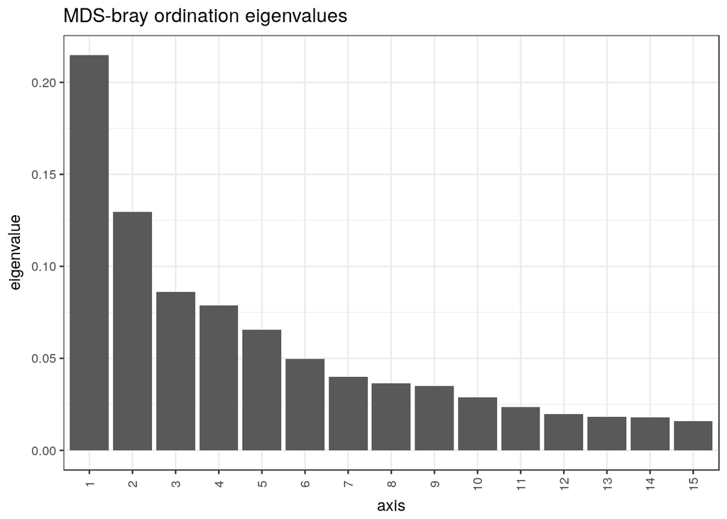

```r
plot_scree(ord) + xlim(as.character(seq(1,15))) + ggtitle("MDS-bray ordination eigenvalues")
```

The first two or so look significant, but after that it’s hard to tell Plot histograms to get a better idea of where to draw the cutoff

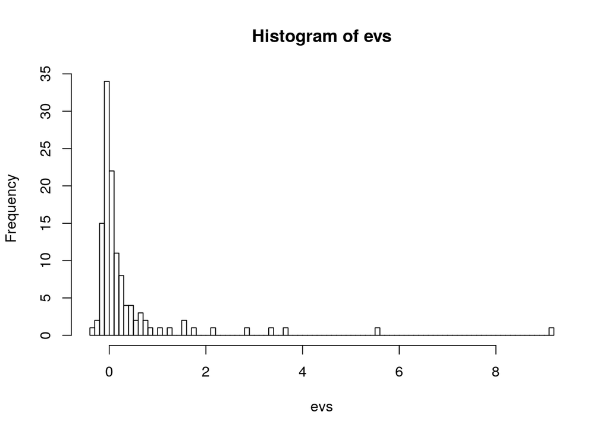

```r
evs <- ord$value$Eigenvalues
h_all <- hist(evs, 100)
```

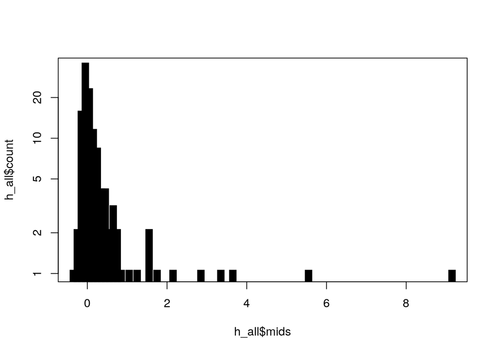

```r
plot(h_all$mids, h_all$count, log="y", type='h', lwd=10, lend=2)
```

Choose eigenvalues 1-5 -> 5 MDS dimensions

## Determine the number of clusters

```r
NDIM <- 5
```

Determine the number of clusters using the gap statistic  
Use the selection criteria proposed by Tibshirani et al (2001)

```r
x <- ord$vectors[,1:NDIM]

pamPCoA = function(x, k) {
    list(cluster = pam(x[,1:2], k, cluster.only = TRUE))
}

set.seed(04122018) # today's date
gap_stat = clusGap(x, FUN = pamPCoA, K.max = 10, B = 100)
```

```
## Clustering k = 1,2,..., K.max (= 10): .. done
## Bootstrapping, b = 1,2,..., B (= 100)  [one "." per sample]:
## .................................................. 50
## .................................................. 100
```

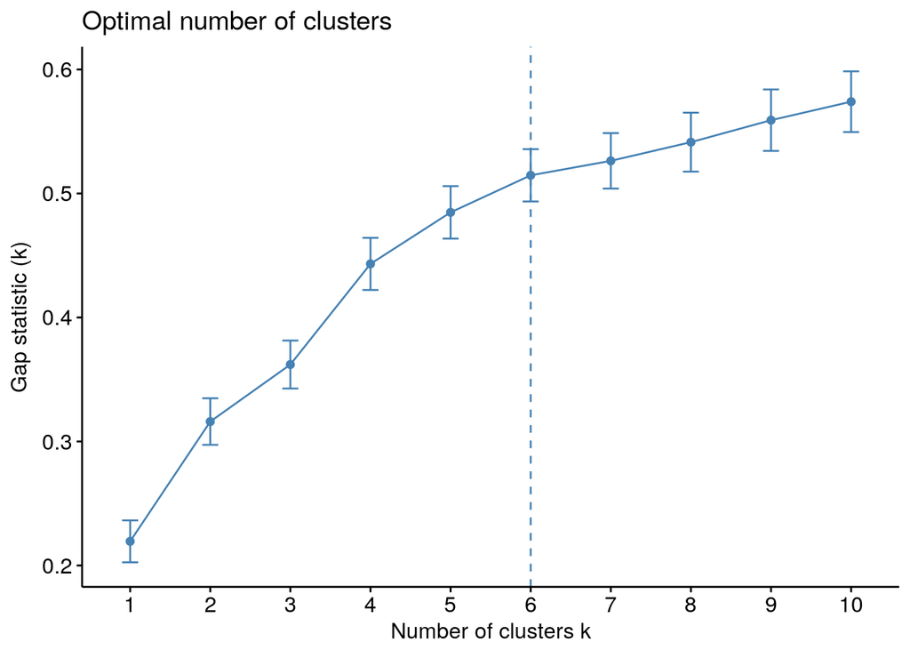

```r
fviz_gap_stat(gap_stat, maxSE = list(method = "Tibs2001SEmax"))
```

Based on this analysis, it appears there are six clusters

## Perform clustering

```r
K <- 6
x <- ord$vectors[,1:NDIM]
clust <- as.factor(pam(x, k=K, cluster.only=T))
sample_data(ps_rectal)$CP <- clust
CPs <- as.character(seq(K))
```

Save identified CPs in the phyloseq “ps_rectal” and “ps_rectal_orig” objects for later use

```r
sample_data(ps_rectal)$CP <- clust
sample_data(ps_rectal_orig)$CP <- clust
```

## Visualize clustering results with MDA ordination

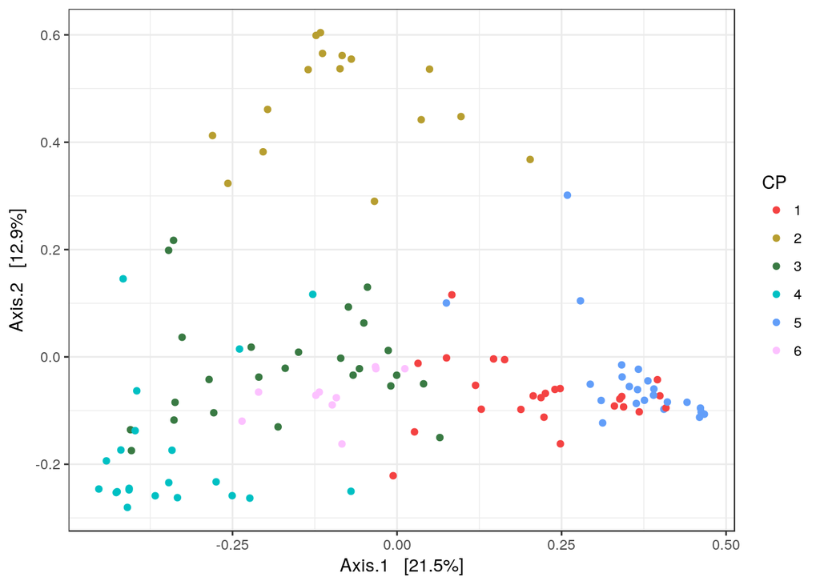

```r
p = plot_ordination(ps_rectal, ord, color="CP") +
    scale_color_manual(values=c("#f44242","#b79e30","#397a43", "#00c0c3", "#629ef9", "#fcc1ff"))
plot(p)
```

## Perform redundancy analysis (RDA)

```r
#Perform ordination by community profile
ps_rectal.ord <- ordinate(ps_rectal, "RDA", "bray", formula=ps_rectal~CP)
evals <- eigenvals(ps_rectal.ord)

#Plot the CP ordination and add biplot with taxa, scale axes by magnitude of variance explained
p = plot_ordination(ps_rectal, ps_rectal.ord, type="biplot", color="CP") +
    coord_fixed(sqrt(evals[2] / evals[1]))

# Adjust aesthetic parameters of ordination
p = p +  scale_size_manual(values=c(2,2,2,2)) +
    # grey (taxa)
    scale_color_manual(values=c("#9a9c9e","#f44242","#b79e30","#397a43", "#00c0c3", "#629ef9", "#fcc1ff"))
```

[output not shown]

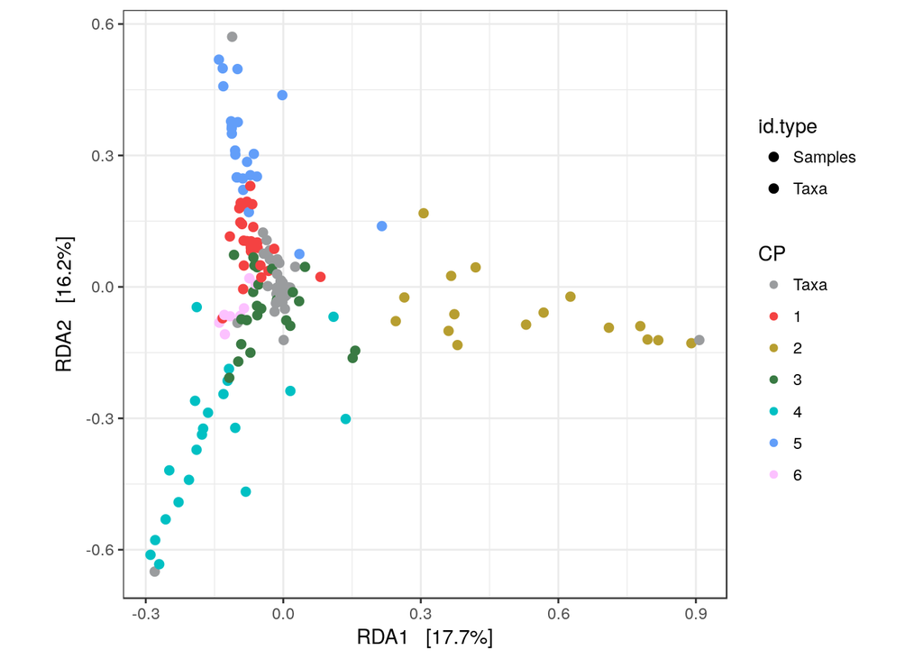

```r
plot(p)
```

```r
ggsave('rda_rectal.pdf', plot = p)
```